# Shifting distributions and long-term changes in marine assemblage richness

Ryan Batt

2015-08-23

Abstract

These are the results and figures.

# Results

## Species Richness

### Richness Summary

Give a basic summary of species richness stats. For example, the regions with the lowest and highest long-term averages in species richness are:

```r
kable(comm_master[,mean(reg_rich), by='reg'][reg%in%c("gmex","shelf")])
```

| reg | V1 |
| --- | --- |
| gmex | 142.28522 |
| shelf | 46.29991 |

Can also measure long-term variability of the different regions. Here is the standard deviation for each region:

```r
kable(comm_master[,stats::sd(reg_rich),by='reg'])
```

| reg | V1 |
| --- | --- |
| ai | 2.444883 |
| ebs | 5.566457 |
| gmex | 4.266274 |
| goa | 8.506057 |
| neus | 8.237090 |
| newf | 4.365340 |
| sa | 4.035492 |
| shelf | 3.246860 |
| wctri | 7.153178 |

And here is the cross-region average of those long-term standard deviations:

```r
kable(comm_master[,stats::sd(reg_rich),by='reg'][,mean(V1)])
```

| 5.313515 |
| --- |

#### Figure 1. MSOM richness time series

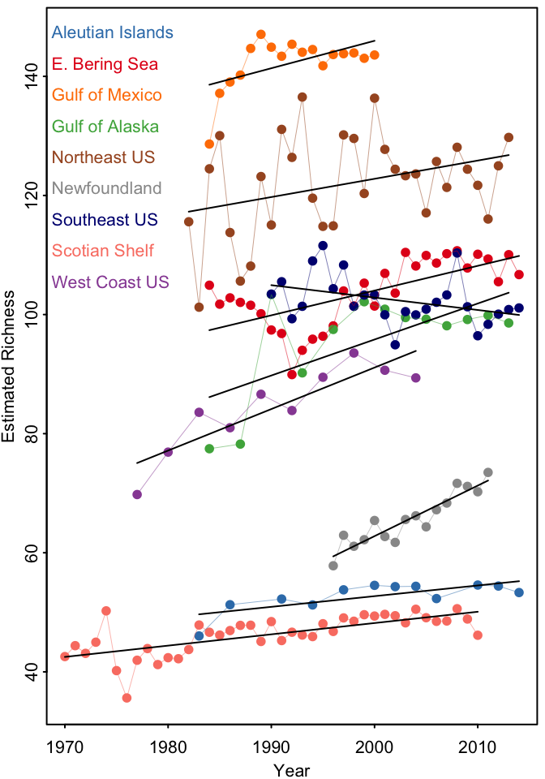

**Figure 1.** Time series of MSOM estimates of region richness. Each point is the posterior mean of regional richness in a year. Lines indicate long-term trends from fitted values of linear regression models predicting richness from time.

```r
richness_ts()
```

#### Figure S1. MSOM - naive scatter

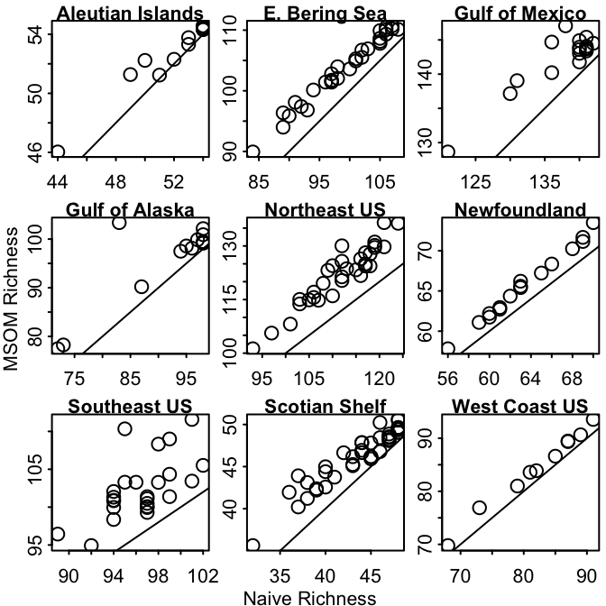

**Figure S1.** MSOM richness vs naive richness

```r
naive_msom_scatter()
```

MSOM richness and Naive richness are pretty similar. MSOM richness is probably more accurate, or is at least more conservative b/c it has fewer significant trends. But their similarity should help justify using observed presences/ absences in other analyses.

**Manuscript paragraph:**  
MSOM estimates of richness were greater than Naive estimates, but the two methods produced similar temporal dynamics in richness (Figure S1). Henceforth, we report MSOM richness estimates. The greatest long-term average richness was the Gulf of Mexico (142.3), lowest in the Scotian Shelf (46.3). The inter-region average of long-term standard deviations of richness was 5.3; the Aleutian Islands showed the lowest variability (sd = 2.4), and the Gulf of Alaska was the most variable (sd = 8.5).